# Capstone Project

Sheila Pratt

3/14/2017

## US Motor Vehicle Fatalities - How Vehicle Age & Model Year Relates to Fatalities

##### Research Question

[output not shown]

```r
library(readstata13)
library(dplyr)
library(knitr)
library(devtools)
library(DT)
library(xtable)
library(ggplot2)
library(gmodels)
library(reshape2)
library(MASS)
library(vcd)
library(caret)
library(ISLR)
library(SDMTools)
#setwd("~/Desktop/R/")
```

#### Step 1: Load data, and run numerical and graphical summeries

### The Dataset

The accident data in this analysis was loaded via .cvs (2015) and .dta (2012-2014) formatted data files by (accident) year. The data for each year consists of 3 files; Person, Vehicle and Accident.

The Vehicle data file contains information describing in-transport motor vehicles and drivers who are involved in a fatal crash. There is one record per in-transport motor vehicle.

The Person data file contains information describing all persons involved in the crash including motorists (i.e., drivers and passengers of in-transport motor vehicles) and non-motorists (e.g., pedestrians and pedalcyclists). It provides information such as age, vehicle occupant restraint use, and injury severity. There is one record per person.

The Accident data file contains information about crash characteristics and environmental conditions at the time of the crash. There is one record per crash. Fatal crashes only

```
Loading Data into Data Frames by year      #http://www.nber.org/data/fars.html
```

```r
v_veh_2015<-read.csv("veh_aux.csv",header=TRUE)
v_per_2015<-read.csv("per_aux.csv",header=TRUE)
v_acc_2015<-read.csv("acc_aux.csv",header=TRUE)
v_acc_2014<-read.dta13("acc_aux2014.dta")
v_veh_2014<-read.dta13("veh_aux2014.dta")
v_per_2014<-read.dta13("per_aux2014.dta")
v_acc_2013<-read.dta13("acc_aux2013.dta")
v_veh_2013<-read.dta13("veh_aux2013.dta")
v_per_2013<-read.dta13("per_aux2013.dta")
v_acc_2012<-read.dta13("acc_aux2012.dta")
v_veh_2012<-read.dta13("veh_aux2012.dta")
v_per_2012<-read.dta13("per_aux2012.dta")
```

### The Data Cleansing Process

#### Review Raw Data

```r
#Data Frame Structure
#str(v_veh_2015)    #Compare vehicle, accident and person file for each year.  Also compare year over year files.
```

```
Analysis of str() results:
a)  Total number of variables (columns) and observations (rows)
b)  Variable class (data type)
c)  Structure class (i.e. data.frame)
d)  Sample of data, first 10 values
e)  Variable Names (incl upper/lower case)
```

#### Results:

```
All variables are integers and will need to be converted into factors.  Variable names are not consistent across years and will be converted to all upper case.  All years are consistent across the respective vehicle, accident and person files, except for 2012 which is missing 2 variables.

2015 acc - 38 variables, 31266 rows
2015 veh - 16 variables, 48923 rows
2015 per - 22 variables, 80587 rows
2014 acc - 38 variables, 30056 rows
2014 veh - 16 variables, 44950 rows
2014 per - 22 variables, 73711 rows
2013 acc - 38 variables, 30202 rows
2013 veh - 16 variables, 45101 rows
2013 per - 22 variables, 74331 rows
2012 acc - 36 variables, 31006 rows
2012 veh - 16 variables, 45960 rows
2012 per - 22 variables, 76436 rows
```

#### Check for Missing Values (NA’s, NaN’s):

```
In the 2012 - 2014 files, variable A_IMP_2 has missing values (NA).  The 2015 file is populated with all zeros.  As per the FARS documentation A_IMP_2 (Principle Impact Point) was no longer populated as of 2012. The variable will be deleted.  There is no other missing data.
```

```r
sapply(v_veh_2015, function(x) sum(is.na(x)))
```

```
##     YEAR  ST_CASE   VEH_NO   A_BODY   A_IMP1   A_IMP2  A_VROLL  A_LIC_S
##        0        0        0        0        0        0        0        0
##  A_LIC_C  A_CDL_S A_MC_L_S  A_SPVEH   A_SBUS A_MOD_YR  A_DRDIS  A_DRDRO
##        0        0        0        0        0        0        0        0
```

```r
sapply(v_veh_2014, function(x) sum(is.na(x)))
```

```
##     year  st_case   veh_no   a_body   a_imp1   a_imp2  a_vroll  a_lic_s
##        0        0        0        0        0    44950        0        0
##  a_lic_c  a_cdl_s a_mc_l_s  a_spveh   a_sbus a_mod_yr  a_drdis  a_drdro
##        0        0        0        0        0        0        0        0
```

#### Check for Data Completeness

##### Vehicle File

```
A_MOD_YR's (Vehicle Model Year) values range from 1923 - 9999.  9999 refers to unknown model years and these rows will be removed from the analysis.
A_BODY (Vehicle Body Type) has values ranging from 1 to 9.  This study is only looking at types 1 - 4 (cars, pickup trucks, SUV & vans).  The other vehicle body types will be removed.
```

```r
apply(v_veh_2015,2,min)
```

```
##     YEAR  ST_CASE   VEH_NO   A_BODY   A_IMP1   A_IMP2  A_VROLL  A_LIC_S
##     2015    10001        1        1        1        0        1        1
##  A_LIC_C  A_CDL_S A_MC_L_S  A_SPVEH   A_SBUS A_MOD_YR  A_DRDIS  A_DRDRO
##        1        1        1        1        1     1923        1        1
```

```r
apply(v_veh_2015,2,max)
```

```
##     YEAR  ST_CASE   VEH_NO   A_BODY   A_IMP1   A_IMP2  A_VROLL  A_LIC_S
##     2015   560130       58        9        7        0        2        4
##  A_LIC_C  A_CDL_S A_MC_L_S  A_SPVEH   A_SBUS A_MOD_YR  A_DRDIS  A_DRDRO
##        3        3        4        2        3     9999        2        2
```

##### Person File

```
A_PTYPE (Person Type) refers to whether the person in the accident was a driver, passenger, etc.  This study is looking at drivers only = 1.  The other person types will be removed.
```

```r
apply(v_per_2015,2,min)
```

```
##   A_AGE1   A_AGE2   A_AGE3   A_AGE4   A_AGE5   A_AGE6   A_AGE7   A_AGE8
##        1        1        1        1        1        1        1        1
##   A_AGE9  ST_CASE   VEH_NO   PER_NO     YEAR  A_PTYPE   A_REST A_ALCTES
##        1    10001        0        1     2015        1        1        1
##   A_HISP   A_RCAT  A_HRACE  A_EJECT A_PERINJ    A_LOC
##        0        0        0        1        1        1
```

```r
apply(v_per_2015,2,max)
```

```
##   A_AGE1   A_AGE2   A_AGE3   A_AGE4   A_AGE5   A_AGE6   A_AGE7   A_AGE8
##        5        6       13        8       10       10       12        7
##   A_AGE9  ST_CASE   VEH_NO   PER_NO     YEAR  A_PTYPE   A_REST A_ALCTES
##        3   560130       58       51     2015        5        3        5
##   A_HISP   A_RCAT  A_HRACE  A_EJECT A_PERINJ    A_LOC
##        3        8        9        3        6        5
```

##### Accident File

```
A_CRAINJ (Crash Injury Type) has only 1 value, 1 = Fatality, which refers to injury severity.  This variable is redundant for the purposes of this study and will be removed.
```

```r
apply(v_acc_2015,2,min)
```

```
##      YEAR     STATE   ST_CASE    COUNTY    FATALS  A_CRAINJ  A_REGION
##      2015         1     10001         1         1         1         1
##      A_RU   A_INTER   A_RELRD  A_INTSEC  A_ROADFC    A_JUNC  A_MANCOL
##         1         1         1         1         1         1         1
##     A_TOD     A_DOW      A_CT      A_LT      A_MC   A_SPCRA     A_PED
##         1         1         1         1         1         1         1
##   A_PED_F   A_PEDAL A_PEDAL_F    A_ROLL  A_POLPUR  A_POSBAC  A_D15_19
##         1         1         1         1         1         1         1
##  A_D16_19  A_D15_20  A_D16_20  A_D65PLS  A_D21_24  A_D16_24      A_RD
##         1         1         1         1         1         1         1
##      A_HR    A_DIST  A_DROWSY
##         1         1         1
```

```r
apply(v_acc_2015,2,max)
```

```
##      YEAR     STATE   ST_CASE    COUNTY    FATALS  A_CRAINJ  A_REGION
##      2015        56    560130       999        10         1        10
##      A_RU   A_INTER   A_RELRD  A_INTSEC  A_ROADFC    A_JUNC  A_MANCOL
##         3         3         6         3         7         4         7
##     A_TOD     A_DOW      A_CT      A_LT      A_MC   A_SPCRA     A_PED
##         3         3         3         2         2         2         2
##   A_PED_F   A_PEDAL A_PEDAL_F    A_ROLL  A_POLPUR  A_POSBAC  A_D15_19
##         2         2         2         2         2         3         2
##  A_D16_19  A_D15_20  A_D16_20  A_D65PLS  A_D21_24  A_D16_24      A_RD
##         2         2         2         2         2         2         2
##      A_HR    A_DIST  A_DROWSY
##         2         2         2
```

### Merge Files

```
In order to produce 1 file for each year, it is necessary to identify common variables between vehicle, person and accident files.
```

##### Identify Common Elements Within Each Year

```r
veh2013<-names(v_veh_2013)
per2013<-names(v_per_2013)
acc2013<-names(v_acc_2013)
veh2012<-names(v_veh_2012)
per2012<-names(v_per_2012)
acc2012<-names(v_acc_2012)

intersect(veh2013,per2013)
```

```
## [1] "year"    "st_case" "veh_no"
```

```r
intersect(per2013,acc2013)
```

```
## [1] "st_case" "year"
```

```r
intersect(veh2013,acc2013)
```

```
## [1] "year"    "st_case"
```

```
ST_CASE is the unique case number assigned to each crash. It appears on each data file and is used to merge information from the data files together.

VEH_NO identifies the “Vehicle Number”.  Each vehicle in an accident is assigned a unique number.  ST_CASE and VEH_NO are the unique identifiers for each record and are used to merge the Vehicle File with the Person file.

YEAR records the year in which the crash occurred and is used to merge files from the same year.
```

##### Identify Differences Between Years

```
In order to combine all yearly files into 1 master file, it is necessary to ensure all files have the same variables.
```

```r
setdiff(acc2013,acc2012)
```

```
## [1] "a_ped_f"   "a_pedal_f"
```

### Inner Join

[output not shown]

```r
#MERGE FILES
m_perveh_2015<-inner_join(v_veh_2015,v_per_2015, by=c("ST_CASE","YEAR","VEH_NO"))
m_perveh_2014<-inner_join(v_veh_2014,v_per_2014, by=c("st_case","year","veh_no"))
m_perveh_2013<-inner_join(v_veh_2013,v_per_2013, by=c("st_case","year","veh_no"))
m_perveh_2012<-inner_join(v_veh_2012,v_per_2012, by=c("st_case","year","veh_no"))

m_pervehacc_2015<-inner_join(m_perveh_2015,v_acc_2015, by=c("ST_CASE","YEAR"))
m_pervehacc_2014<-inner_join(m_perveh_2014,v_acc_2014, by=c("st_case","year"))
m_pervehacc_2013<-inner_join(m_perveh_2013,v_acc_2013, by=c("st_case","year"))
m_pervehacc_2012<-inner_join(m_perveh_2012,v_acc_2012, by=c("st_case","year"))

dim(m_pervehacc_2013)   #check
```

```
## [1] 67903    71
```

```r
dim(m_pervehacc_2012)   #check
```

```
## [1] 69982    69
```

#### Convert Column Headings to all upper case

```r
colnames(m_pervehacc_2014)<-toupper(colnames(m_pervehacc_2014))
colnames(m_pervehacc_2013)<-toupper(colnames(m_pervehacc_2013))
colnames(m_pervehacc_2012)<-toupper(colnames(m_pervehacc_2012))
```

```r
names(m_pervehacc_2014)      #check
```

#### Remove Inconsistent (and Unused) Variables (“a_ped_f”,“a_pedal_f”)

```r
m_pervehacc_2014[c(55,57)]<-NULL
m_pervehacc_2015[c(55,57)]<-NULL
m_pervehacc_2013[c(55,57)]<-NULL

dim(m_pervehacc_2012)    #check
```

```
## [1] 69982    69
```

```r
dim(m_pervehacc_2013)    #check
```

```
## [1] 67903    69
```

#### Merge Files from all Years

```r
fatal <- rbind(m_pervehacc_2014, m_pervehacc_2015, m_pervehacc_2013, m_pervehacc_2012)
table(fatal$YEAR)
```

```
##
##  2012  2013  2014  2015
## 69982 67903 67102 73390
```

### Data Filters

#### Delete Variables

```
A_IMP2 - Principle Impact Point
A_IMP2 contains all zeros for 2015 and all NA's for the other years. The variable is longer populated as of 2012.
```

```r
fatal[6]<-NULL
```

```
A_CRAINJ - Crash Injury Type
(inj_sev = 0, 1, 2, 3, 5) passenger vehicle drivers - all values are 1 = fatal crash
```

```r
fatal[38]<-NULL
```

```
A_PED - Pedestrian, A_PEDAL - Cyclist are not used.
```

```r
fatal[c(52,53)]<-NULL
```

#### Variable Filters

[output not shown]

```r
table(fatal$A_BODY)
```

```
##
##      1      2      3      4      5      6      7      8      9
## 113501  47787  49664  17111    628  18008  21989   3693   5996
```

```r
#Passenger Vehicles Only
fatal<-subset(fatal, A_BODY<5) #Restrict to cars, pickup trucks, SUV & vans
table(fatal$A_BODY)   #check
```

```
##
##      1      2      3      4
## 113501  47787  49664  17111
```

```r
table(fatal$A_PTYPE)
```

```
##
##      1      2
## 142464  85599
```

```r
#Vehicle Driver
fatal<-fatal%>% filter(A_PTYPE==1.0) #Restrict to Drivers only
#table(fatal$A_PTYPE) #check
```

```r
min(fatal$A_MOD_YR)
```

```
## [1] 1914
```

```r
#Model Year
fatal <- subset(fatal, A_MOD_YR>1984) #Restrict to model years after 1984
min(fatal$A_MOD_YR)  #check
```

```
## [1] 1985
```

## Data Analysis

### Injury Type

[output not shown]

##### Injury Type - Convert to Factor

```r
fatal$A_PERINJ.F<-factor(fatal$A_PERINJ,labels=c("Fatal","Survived"))
```

##### Injury Type - Data Analysis

```r
#COUNT WITH TOTALS
kable(addmargins(table(fatal$YEAR,fatal$A_PERINJ.F)),margin=2,align=NULL,caption="Injury Severity Count Totals by Year")
```

Injury Severity Count Totals by Year

|  | Fatal | Survived | Sum |
| --- | --- | --- | --- |
| 2012 | 15615 | 19376 | 34991 |
| 2013 | 15282 | 18968 | 34250 |
| 2014 | 15247 | 19224 | 34471 |
| 2015 | 16218 | 21369 | 37587 |
| Sum | 62362 | 78937 | 141299 |

```r
#PERCENTAGE
inj.ta<-table(fatal$YEAR,fatal$A_PERINJ.F)
kable(prop.table(inj.ta,margin=1),align=NULL,digits=2,caption="Injury Severity % by Year")
```

Injury Severity % by Year

|  | Fatal | Survived |
| --- | --- | --- |
| 2012 | 0.45 | 0.55 |
| 2013 | 0.45 | 0.55 |
| 2014 | 0.44 | 0.56 |
| 2015 | 0.43 | 0.57 |

```r
#PERCENTAGE OVERALL
table1c<-table(fatal$A_PERINJ.F)
table1df<-as.data.frame(table1c)
table1df$percent<- prop.table(table1df$Freq)
names(table1df)<-c("Injury_Severity","Count","2013-2015(%)")
kable(table1df,align=NULL,digits=2,caption="Total Injury Severity")
```

Total Injury Severity

[output not shown]

### Vehicle Age

[output not shown]

```r
fatal$V.AGE<-fatal$YEAR-fatal$A_MOD_YR
table(fatal$V.AGE)
```

```
##
## -7987 -7986 -7985 -7984    -1     0     1     2     3     4     5     6
##    91    87   105   158   380  4755  5956  5296  5001  5480  6048  6887
##     7     8     9    10    11    12    13    14    15    16    17    18
##  8278  8943  9212  9512  8923  8920  8030  7382  6365  5239  4406  3675
##    19    20    21    22    23    24    25    26    27    28    29    30
##  2836  2277  1812  1367  1061   853   675   497   403   216   119    54
```

##### Vehicle Age - Data Cleanup

```
(-7985) represents unknown model years.  These rows should be removed completely.
(-1) represents late model vehicles).  These values will be changed to zero.
```

```r
###Filters
fatal<-fatal%>% filter(V.AGE>-2)
fatal$V.AGE[fatal$V.AGE==-1]<-0 #replace next model year with current)
#table(fatal$V.AGE) #check
```

##### Vehicle Age - Factor Conversion

```
The vehicle age is converted to a factor variable with the buckets of 0-3, 4-7, 8-11, 12-14, 15-17 and 18+ years.
```

```r
fatal$V.AGE_R<-cut(fatal$V.AGE, breaks=c(-Inf,4,8,12,15,18,Inf), labels=c("0-3 yr","4-7 yr","8-11 yr","12-14 yr","15-17 yr","18+ yr"),right=FALSE)
#table(fatal$V.AGE_R,fatal$V.AGE) #check
```

##### Vehicle Age - Analysis

```r
kable(prop.table(table(fatal$V.AGE_R,fatal$A_PERINJ.F),margin=1),digits=2,align=NULL,caption="Injury Severity by Vehicle Age (%)")
```

Injury Severity by Vehicle Age (%)

|  | Fatal | Survived |
| --- | --- | --- |
| 0-3 yr | 0.31 | 0.69 |
| 4-7 yr | 0.38 | 0.62 |
| 8-11 yr | 0.44 | 0.56 |
| 12-14 yr | 0.49 | 0.51 |
| 15-17 yr | 0.52 | 0.48 |
| 18+ yr | 0.57 | 0.43 |

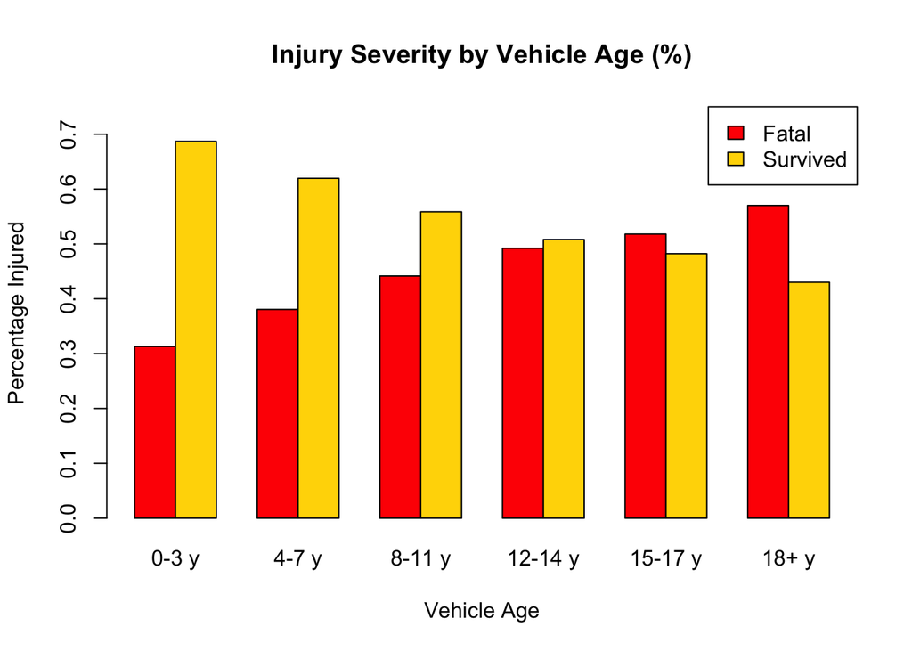

```r
va<-prop.table(table(fatal$A_PERINJ.F,fatal$V.AGE_R),margin=2)
barplot(va,main="Injury Severity by Vehicle Age (%)", xlab="Vehicle Age", ylab="Percentage Injured",col=c("red","gold"),names.arg=c("0-3 y","4-7 y","8-11 y","12-14 y","15-17 y","18+ y"),beside=TRUE,ylim=c(0,0.75),legend.text=TRUE,args.legend=list(x="topright",bty="y",.5:.5))
```

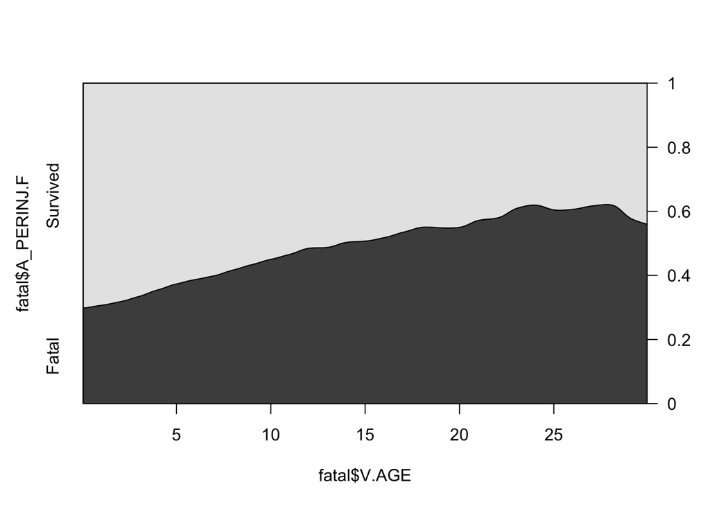

```r
cd_plot(fatal$A_PERINJ.F ~ fatal$V.AGE)
```

### Model Year

```
This report examines how a vehicle’s age and model year relate to a driver’s injury severity in a fatal crash.
```

```r
#####Model Year - Factor Conversion
fatal$A_MOD_YR.F<-cut(fatal$A_MOD_YR, breaks=c(-Inf,1991,1996,2001,2006,2011,Inf), labels=c("MV 1985-1990","MV 1991-1995","MV 1996-2000","MV 2001-2005","MV 2006-2010","MV 2011-2015"),right=FALSE) #create factor with levels and labels

fatal$A_MOD_YR.F<-factor(fatal$A_MOD_YR.F,levels = rev(levels(fatal$A_MOD_YR.F))) #reverse order
#levels(fatal$A_MOD_YR.F) #check
```

##### Model Year - Data Analysis

```r
kable(prop.table(table(fatal$A_MOD_YR.F,fatal$A_PERINJ.F),margin=1),digits=2,align=NULL,caption="Injury Severity by Model Year (%)")
```

Injury Severity by Model Year (%)

|  | Fatal | Survived |
| --- | --- | --- |
| MV 2011-2015 | 0.31 | 0.69 |
| MV 2006-2010 | 0.38 | 0.62 |
| MV 2001-2005 | 0.46 | 0.54 |
| MV 1996-2000 | 0.51 | 0.49 |
| MV 1991-1995 | 0.57 | 0.43 |
| MV 1985-1990 | 0.61 | 0.39 |

[output not shown]

[figure not shown]

```r
#Vehicle Age is stratified into MV Years

study<-as.data.frame(addmargins(table(fatal$V.AGE_R,fatal$A_MOD_YR.F)))
colnames(study) <- c("Vehage","Modelyear","TotPer")

my_fatal<-fatal%>% filter(A_PERINJ==1) #Fatal Only
my_surv<-fatal%>% filter(A_PERINJ==6) #Survived Only

studyf<-as.data.frame(addmargins(table(my_fatal$V.AGE_R,my_fatal$A_MOD_YR.F)))

colnames(studyf) <- c("Vehage","Modelyear","FatPer")

studyc<-cbind(study,studyf[3])
studyc$Percentage<-round(studyc$FatPer/studyc$TotPer,digits=2)

studyc$Percentage[is.na(studyc$Percentage)]<- 0

attach(studyc)

study<-studyc%>% filter(Vehage!="Sum",Modelyear!="Sum")
studyplot<-study[c(-3,-4)]

g<-ggplot(studyplot,aes(Modelyear,Percentage,fill = Modelyear))
g<-g + geom_bar(stat = "identity", width = 0.5, position = "dodge")
g + ggtitle("Percentage Killed by Model Year (FARS 2013-2015)")
```

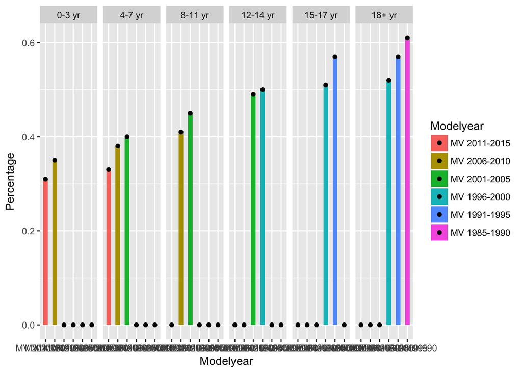

[output not shown]

```r
g+geom_point()+facet_grid(.~Vehage)
```

```r
myear.ta<-table(my_fatal$A_MOD_YR.F,my_fatal$V.AGE_R)
kable(myear.ta)
```

|  | 0-3 yr | 4-7 yr | 8-11 yr | 12-14 yr | 15-17 yr | 18+ yr |
| --- | --- | --- | --- | --- | --- | --- |
| MV 2011-2015 | 5553 | 491 | 0 | 0 | 0 | 0 |
| MV 2006-2010 | 1143 | 8768 | 2730 | 0 | 0 | 0 |
| MV 2001-2005 | 0 | 898 | 13425 | 6185 | 0 | 0 |
| MV 1996-2000 | 0 | 0 | 0 | 5787 | 7716 | 1402 |
| MV 1991-1995 | 0 | 0 | 0 | 0 | 575 | 5558 |
| MV 1985-1990 | 0 | 0 | 0 | 0 | 0 | 2072 |

```r
#barplot(prop.table(myear.ta,margin=2),main = "Percentage Killed by Vehicle Age and Model Year",beside=TRUE,legend=TRUE,col=c("orange","darkblue","green","yellow","red","purple"))
```

### Restraint Use

```
Driver restraint use plays a large role in the relationship between vehicle age and the percentage of drivers who were fatally injured.
```

##### Restraint Use - Factor Conversion

```r
fatal$A_REST.F<-factor(fatal$A_REST,labels=c("Restraint","No Restraint","Unknown"))
```

```r
my_fatal$A_REST.F<-factor(my_fatal$A_REST,labels=c("Restraint","No Restraint","Unknown"))
```

```r
CrossTable(fatal$A_REST.F,fatal$A_PERINJ.F,prop.t=FALSE,prop.r=TRUE,prop.c=FALSE,digits=2,missing.include=TRUE,prop.chisq = FALSE,dnn=c("Restraint Use","Injury Severity"))
```

```
##
##
##    Cell Contents
## |-------------------------|
## |                       N |
## |           N / Row Total |
## |-------------------------|
##
##
## Total Observations in Table:  140858
##
##
##               | Injury Severity
## Restraint Use |     Fatal |  Survived | Row Total |
## --------------|-----------|-----------|-----------|
##     Restraint |     29526 |     64981 |     94507 |
##               |      0.31 |      0.69 |      0.67 |
## --------------|-----------|-----------|-----------|
##  No Restraint |     28030 |      7229 |     35259 |
##               |      0.79 |      0.21 |      0.25 |
## --------------|-----------|-----------|-----------|
##       Unknown |      4747 |      6345 |     11092 |
##               |      0.43 |      0.57 |      0.08 |
## --------------|-----------|-----------|-----------|
##  Column Total |     62303 |     78555 |    140858 |
## --------------|-----------|-----------|-----------|
##
##
```

```r
my_rest<-fatal%>%filter(A_REST==1) #Restrained Driver
my_norest<-fatal%>%filter(A_REST==2) #Not Restrained Driver
```

```r
#CrossTable(fatal$A_PERINJ.F,fatal$A_REST.F,prop.t=FALSE,prop.r=TRUE,prop.c=FALSE,digits=2,missing.include=TRUE,prop.chisq = FALSE,dnn=c("Restraint Use","Injury Severity"))
```

##### SPLIT RESTRAINED VS NONRESTRAINED

```r
my_rest<-fatal%>%filter(A_REST==1) #Restrained Driver
my_norest<-fatal%>%filter(A_REST==2) #Not Restrained Driver
```

##### Restrained Drivers - Injury Severity by Vehicle Age

```r
ry<-table(my_rest$V.AGE_R,my_rest$A_PERINJ.F)
kable(prop.table(ry,margin=1),align=NULL,digits=2)
```

|  | Fatal | Survived |
| --- | --- | --- |
| 0-3 yr | 0.24 | 0.76 |
| 4-7 yr | 0.28 | 0.72 |
| 8-11 yr | 0.31 | 0.69 |
| 12-14 yr | 0.35 | 0.65 |
| 15-17 yr | 0.37 | 0.63 |
| 18+ yr | 0.43 | 0.57 |

[output not shown]

```r
rky<-table(my_rest$V.AGE,my_rest$A_PERINJ.F)
rk.py<-prop.table(rky, margin=1)
rk.py<-as.data.frame(rk.py)

rk.p_1y<-subset(rk.py,Var2=="Fatal",select=c(Var1,Var2,Freq))
rk.p_1_22y<-rk.p_1y[1:22,]
names(rk.p_1_22y)<-c("V.AGE","INJURY","INJ%")
```

[output not shown]

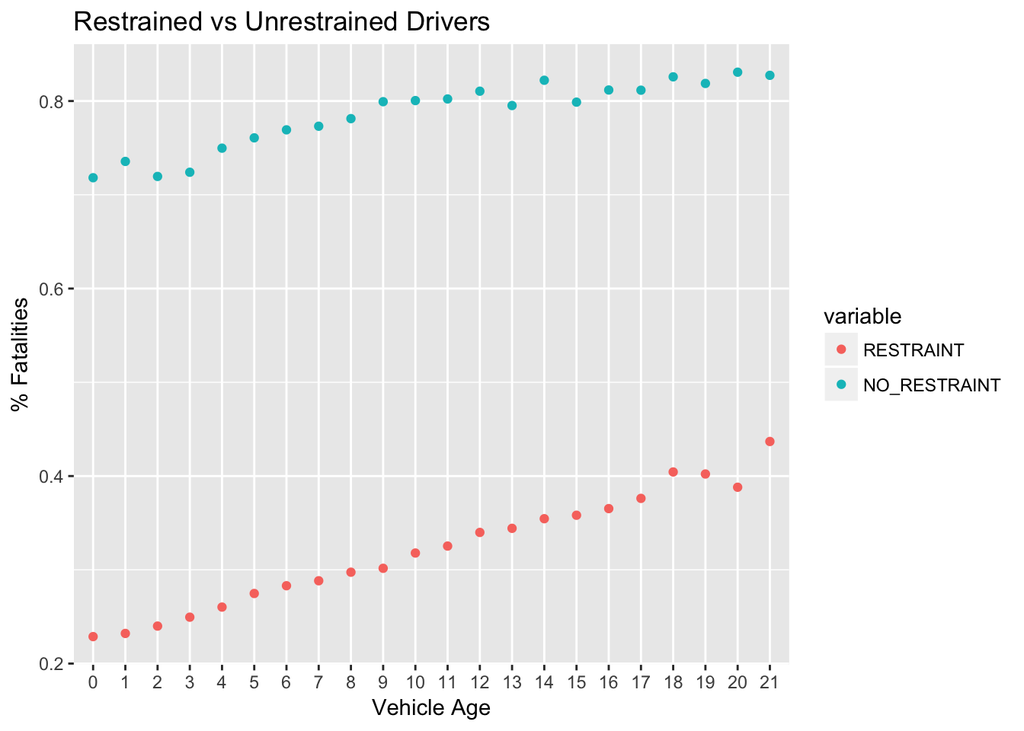

```r
rkny<-table(my_norest$V.AGE,my_norest$A_PERINJ)
rk.pny<-prop.table(rkny, margin=1)
rk.pny<-as.data.frame(rk.pny)

rk.p_1ny<-subset(rk.pny,Var2=="1",select=c(Var1,Var2,Freq))
rk.p_1_22ny<-rk.p_1ny[1:22,]
names(rk.p_1_22ny)<-c("V.AGE","INJURY","INJ%")

df2y <- subset(rk.p_1_22y,select=c("V.AGE","INJ%"))
df3y <- subset(rk.p_1_22ny,select="INJ%")
df4y<-cbind(df2y,df3y)
names(df4y)<-c("V.AGE","RESTRAINT","NO_RESTRAINT")
df5y <- melt(df4y, measure.vars = c("RESTRAINT", "NO_RESTRAINT"))
(ply <- ggplot(df5y, aes(V.AGE, value, colour = variable, lour=V.AGE, group=V.AGE)) + geom_point() + ggtitle("Restrained vs Unrestrained Drivers") + labs(x="Vehicle Age",y="% Fatalities"))
```

##Driver’s Age

```r
#REMOVE UNKNOWN VALUES FOR AGE OF DRIVERS
fatal <- subset(fatal, A_AGE3!=13) #remove driver's age if 'unknown'
my_fatal <- subset(my_fatal, A_AGE3!=13) #remove driver's age if 'unknown'
#table(fatal$A_AGE3) #check
```

```r
fatal$A_AGE3.F<-factor(fatal$A_AGE3)
levels(fatal$A_AGE3.F)<-c("<21","<21","<21","21-24","25-34","35-44","45-54","55-65","65-75","75+")
my_fatal$A_AGE3.F<-factor(my_fatal$A_AGE3)
levels(my_fatal$A_AGE3.F)<-c("<21","<21","<21","21-24","25-34","35-44","45-54","55-65","65-75","75+")
#table(fatal$A_AGE3,fatal$A_AGE3.F) #check
```

### Vehicle Body Type

```r
fatal$A_BODY.F<-factor(fatal$A_BODY,labels=c("Car","Pickup","SUV","Van"))
my_fatal$A_BODY.F<-factor(my_fatal$A_BODY,labels=c("Car","Pickup","SUV","Van"))
fbodyy<-table(fatal$A_BODY.F,fatal$A_PERINJ.F)
kable(prop.table(fbodyy,margin=1),align=NULL,digits=2,caption="Vehicle Body Type Survival Rates")
```

Vehicle Body Type Survival Rates

|  | Fatal | Survived |
| --- | --- | --- |
| Car | 0.49 | 0.51 |
| Pickup | 0.42 | 0.58 |
| SUV | 0.39 | 0.61 |
| Van | 0.33 | 0.67 |

```r
summary(fbodyy)
```

```
## Number of cases in table: 140349
## Number of factors: 2
## Test for independence of all factors:
##  Chisq = 1476.9, df = 3, p-value = 5.922e-320
```

```r
table(my_fatal$A_BODY.F,my_fatal$V.AGE_R)
```

```
##
##          0-3 yr 4-7 yr 8-11 yr 12-14 yr 15-17 yr 18+ yr
##   Car      4576   6572    8746     6235     4356   4822
##   Pickup    943   1869    3368     2606     1766   2683
##   SUV       920   1330    3279     2498     1720   1185
##   Van       254    382     755      618      448    341
```

```r
kable(prop.table(table(my_fatal$A_BODY.F,my_fatal$V.AGE_R),margin=1),digits=2,align=NULL,caption="tbd")
```

tbd

|  | 0-3 yr | 4-7 yr | 8-11 yr | 12-14 yr | 15-17 yr | 18+ yr |
| --- | --- | --- | --- | --- | --- | --- |
| Car | 0.13 | 0.19 | 0.25 | 0.18 | 0.12 | 0.14 |
| Pickup | 0.07 | 0.14 | 0.25 | 0.20 | 0.13 | 0.20 |
| SUV | 0.08 | 0.12 | 0.30 | 0.23 | 0.16 | 0.11 |
| Van | 0.09 | 0.14 | 0.27 | 0.22 | 0.16 | 0.12 |

```r
prop.table(fbodyy,margin=1)
```

```
##
##              Fatal  Survived
##   Car    0.4894844 0.5105156
##   Pickup 0.4187231 0.5812769
##   SUV    0.3881551 0.6118449
##   Van    0.3312811 0.6687189
```

```r
c_fbodyy<-chisq.test(fbodyy)$expected
qchisq(.95,df=3)
```

```
## [1] 7.814728
```

```r
prop.table(c_fbodyy,margin=1)
```

```
##
##              Fatal  Survived
##   Car    0.4436939 0.5563061
##   Pickup 0.4436939 0.5563061
##   SUV    0.4436939 0.5563061
##   Van    0.4436939 0.5563061
```

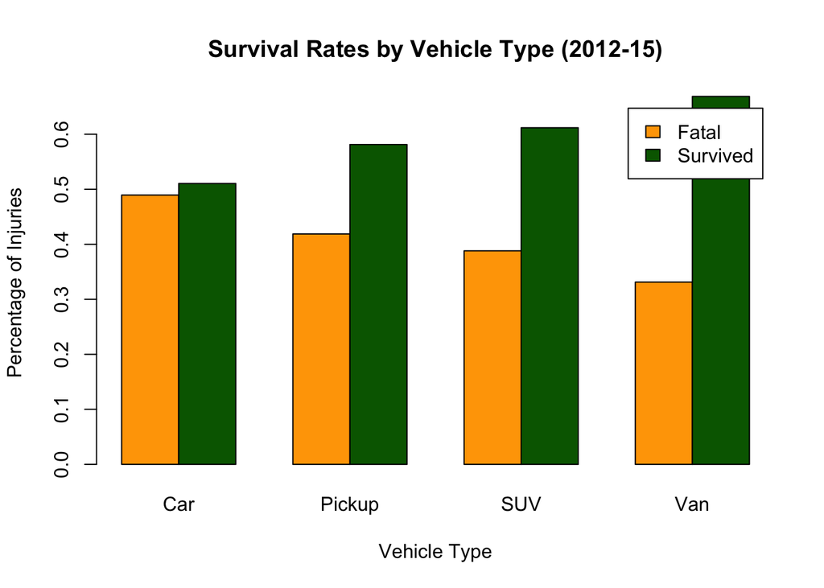

```r
barplot(t(prop.table(fbodyy,margin=1)),main = "Survival Rates by Vehicle Type (2012-15)",beside=TRUE,legend=TRUE, xlab="Vehicle Type", ylab="Percentage of Injuries",col=c("orange","darkgreen"))
```

### Rollover

```r
fatal$A_VROLL.F<-factor(fatal$A_VROLL,labels=c("Rollover","No Rollover"))

my_fatal$A_VROLL.F<-factor(my_fatal$A_VROLL,labels=c("Rollover","No Rollover"))
#table(my_fatal$A_VROLL.F)
my_surv$A_VROLL.F<-factor(my_surv$A_VROLL,labels=c("Rollover","No Rollover"))

rolly.f<-table(my_fatal$A_VROLL.F,my_fatal$V.AGE_R)
rolly.s<-table(my_surv$A_VROLL.F,my_surv$V.AGE_R)

#Fatal
kable(prop.table(rolly.f,margin=2),digits=2)
```

|  | 0-3 yr | 4-7 yr | 8-11 yr | 12-14 yr | 15-17 yr | 18+ yr |
| --- | --- | --- | --- | --- | --- | --- |
| Rollover | 0.22 | 0.28 | 0.35 | 0.36 | 0.36 | 0.32 |
| No Rollover | 0.78 | 0.72 | 0.65 | 0.64 | 0.64 | 0.68 |

```r
#Survived
kable(prop.table(rolly.s,margin=2),digits=2)
```

|  | 0-3 yr | 4-7 yr | 8-11 yr | 12-14 yr | 15-17 yr | 18+ yr |
| --- | --- | --- | --- | --- | --- | --- |
| Rollover | 0.06 | 0.07 | 0.11 | 0.12 | 0.12 | 0.12 |
| No Rollover | 0.94 | 0.93 | 0.89 | 0.88 | 0.88 | 0.88 |

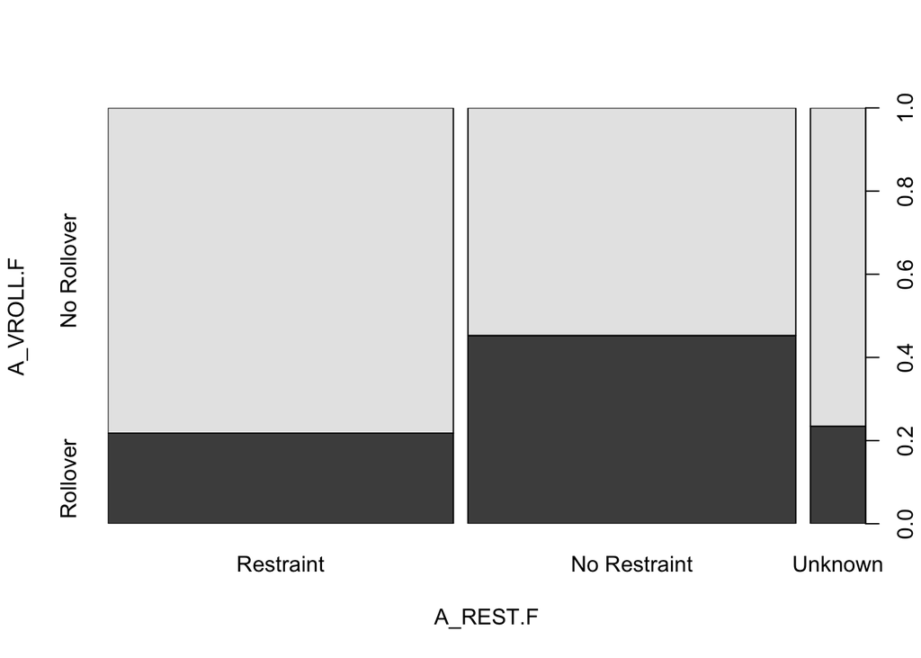

```r
plot(A_VROLL.F~A_REST.F,my_fatal)
```

### FITTING THE MODEL - PREPARATION

##### Relevel and Check Baselines

```r
levels(fatal$A_PERINJ.F) #Fatal = 0, Survived = 1
```

```
## [1] "Fatal"    "Survived"
```

```r
fatal$A_PERINJ.F<-relevel(fatal$A_PERINJ.F, ref="Survived")
levels(fatal$A_PERINJ.F) #Fatal = 1 (Success), Survived = 0 (Fail)
```

```
## [1] "Survived" "Fatal"
```

```r
levels(fatal$V.AGE_R) #reference category = 0-3 years
```

```
## [1] "0-3 yr"   "4-7 yr"   "8-11 yr"  "12-14 yr" "15-17 yr" "18+ yr"
```

```r
#fatal$V.AGE_R<-relevel(fatal$V.AGE_R, ref="4-7 yr")
levels(fatal$V.AGE_R) #reference category = 4-7 years
```

```
## [1] "0-3 yr"   "4-7 yr"   "8-11 yr"  "12-14 yr" "15-17 yr" "18+ yr"
```

```r
fatal$A_MOD_YR.F<-factor(fatal$A_MOD_YR.F,levels = rev(levels(fatal$A_MOD_YR.F)))
levels(fatal$A_MOD_YR.F) #reference category = MV 2011-2015
```

```
## [1] "MV 1985-1990" "MV 1991-1995" "MV 1996-2000" "MV 2001-2005"
## [5] "MV 2006-2010" "MV 2011-2015"
```

```r
fatal$A_POSBAC.F<-factor(fatal$A_POSBAC,labels=c("Positive BAC","Negative BAC","Unknown BAC"))
fatal$A_POSBAC.F<-relevel(fatal$A_POSBAC.F, ref="Negative BAC")
levels(fatal$A_POSBAC.F)
```

```
## [1] "Negative BAC" "Positive BAC" "Unknown BAC"
```

```r
fatal$A_REST.F<-relevel(fatal$A_REST.F, ref="No Restraint")
levels(fatal$A_REST.F) #baseline reference = not restrained
```

```
## [1] "No Restraint" "Restraint"    "Unknown"
```

```r
fatal$A_VROLL.F<-relevel(fatal$A_VROLL.F, ref="No Rollover")
levels(fatal$A_VROLL.F)
```

```
## [1] "No Rollover" "Rollover"
```

```r
levels(fatal$A_BODY.F)
```

```
## [1] "Car"    "Pickup" "SUV"    "Van"
```

```r
fatal$A_SPVEH.F<-factor(fatal$A_SPVEH,labels=c("Speed Involved","Speed Not Involved"))
fatal$A_SPVEH.F<-relevel(fatal$A_SPVEH.F, ref="Speed Not Involved")
levels(fatal$A_SPVEH.F)
```

```
## [1] "Speed Not Involved" "Speed Involved"
```

```r
#fatal$A_AGE3.F<-relevel(fatal$A_AGE3.F, ref="25-34")
levels(fatal$A_AGE3.F)
```

```
## [1] "<21"   "21-24" "25-34" "35-44" "45-54" "55-65" "65-75" "75+"
```

```r
fatal$A_RD.F<-factor(fatal$A_RD,labels=c("Yes","No"))
fatal$A_RD.F<-relevel(fatal$A_RD.F, ref="No")
levels(fatal$A_RD.F)
```

```
## [1] "No"  "Yes"
```

```r
fatal$A_CT.F<-factor(fatal$A_CT,labels=c("Single V.","Two V.", "Three V.+"))
levels(fatal$A_CT.F)
```

```
## [1] "Single V." "Two V."    "Three V.+"
```

```r
fatal$A_EJECT.F<-factor(fatal$A_EJECT,labels=c("Not Ejected","Ejected", "Unknown"))
levels(fatal$A_EJECT.F)
```

```
## [1] "Not Ejected" "Ejected"     "Unknown"
```

```r
fatal$A_RU.F<-factor(fatal$A_RU,labels=c("Rural","Urban","Unknown"))
fatal$A_RU.F<-relevel(fatal$A_RU.F, ref="Urban")
levels(fatal$A_RU.F)
```

```
## [1] "Urban"   "Rural"   "Unknown"
```

```r
fatal$A_TOD.F<-factor(fatal$A_TOD,labels=c("Daytime","Nighttime", "Unknown"))
levels(fatal$A_TOD.F)
```

```
## [1] "Daytime"   "Nighttime" "Unknown"
```

```r
fatal$A_IMP1.F<-factor(fatal$A_IMP1,labels=c("Non-Collision","Front","Right-Side","Rear","Left-Side","Other","Unknown"))
fatal$A_IMP1.F<-relevel(fatal$A_IMP1.F, ref="Front")
levels(fatal$A_IMP1.F)
```

```
## [1] "Front"         "Non-Collision" "Right-Side"    "Rear"
## [5] "Left-Side"     "Other"         "Unknown"
```

```r
fatal$A_DRDRO.F<-factor(fatal$A_DRDRO,labels=c("Drowsy","Other"))
fatal$A_DRDRO.F<-relevel(fatal$A_DRDRO.F, ref="Other")
levels(fatal$A_DRDRO.F)
```

```
## [1] "Other"  "Drowsy"
```

```r
fatal$A_INTSEC.F<-factor(fatal$A_INTSEC,labels=c("Intersection","Non-Intersection","Unknown"))
fatal$A_INTSEC.F<-relevel(fatal$A_INTSEC.F, ref="Non-Intersection")
levels(fatal$A_INTSEC.F)
```

```
## [1] "Non-Intersection" "Intersection"     "Unknown"
```

```r
fatal$A_INTER.F<-factor(fatal$A_INTER,labels=c("Interstate","Non-Interstate","Unknown"))
fatal$A_INTER.F<-relevel(fatal$A_INTER.F, ref="Non-Interstate")
levels(fatal$A_INTER.F)
```

```
## [1] "Non-Interstate" "Interstate"     "Unknown"
```

```r
fatal$A_ROADFC.F<-factor(fatal$A_ROADFC,labels=c("Interstate","Freeway","Main Arterial","Minor Arterial","Collector","Local","Unknown"))
fatal$A_ROADFC.F<-relevel(fatal$A_ROADFC.F, ref="Main Arterial")
levels(fatal$A_ROADFC.F)
```

```
## [1] "Main Arterial"  "Interstate"     "Freeway"        "Minor Arterial"
## [5] "Collector"      "Local"          "Unknown"
```

```r
fatal$A_MANCOL.F<-factor(fatal$A_MANCOL,labels=c("Not wMVIT","Rear-End","Head-On","Angle","Sideswipe","Other","Unknown"))
fatal$A_MANCOL.F<-relevel(fatal$A_MANCOL.F, ref="Head-On")
levels(fatal$A_MANCOL.F)
```

```
## [1] "Head-On"   "Not wMVIT" "Rear-End"  "Angle"     "Sideswipe" "Other"
## [7] "Unknown"
```

```r
fatal$A_DRDIS.F<-factor(fatal$A_DRDIS,labels=c("Distracted","Other"))
fatal$A_DRDIS.F<-relevel(fatal$A_DRDIS.F, ref="Other")
levels(fatal$A_DRDIS.F)
```

```
## [1] "Other"      "Distracted"
```

```r
fatal$A_REGION.F<-factor(fatal$A_REGION,labels=c("New England","Mideast","Atlantic","Southeast","Great Lakes","South","Midwest","Rocky Mountain","Southwest","Northwest"))
fatal$A_REGION.F<-relevel(fatal$A_REGION.F, ref="Southeast")
levels(fatal$A_REGION.F)
```

```
##  [1] "Southeast"      "New England"    "Mideast"        "Atlantic"
##  [5] "Great Lakes"    "South"          "Midwest"        "Rocky Mountain"
##  [9] "Southwest"      "Northwest"
```

### Partition Data into Training/Testing Data Sets

```r
levels(fatal$A_PERINJ.F)
```

```
## [1] "Survived" "Fatal"
```

```r
data<-fatal
attach(data)
levels(A_PERINJ.F)  #(survived, fatal)
```

```
## [1] "Survived" "Fatal"
```

```r
A_PERINJ.F<-factor(A_PERINJ,labels=c("0","1"))
table(A_PERINJ.F)
```

```
## A_PERINJ.F
##     0     1
## 62272 78077
```

```r
levels(A_PERINJ.F)
```

```
## [1] "0" "1"
```

```r
#### Step 2: Split the data into training and testing data

testing<-(YEAR==2015)
training<-!testing
training_data<-data[training,]
testing_data<-data[testing,]
nrow(testing_data) #37271
```

```
## [1] 37271
```

```r
##Fitting the Model

fullmod<-glm(formula = A_PERINJ.F ~ V.AGE_R+A_BODY.F+A_VROLL.F+A_REST.F+A_POSBAC.F+A_SPVEH.F+A_AGE3.F+A_RD.F+A_EJECT.F+A_RU.F+A_TOD.F+A_CT.F+A_MOD_YR.F+A_DRDRO.F+A_INTSEC.F+A_INTER.F+A_ROADFC.F+A_MANCOL.F+A_IMP1.F+A_DRDIS.F+A_REGION.F, family = binomial, data = training_data)
summary(fullmod)
```

```
##
## Call:
## glm(formula = A_PERINJ.F ~ V.AGE_R + A_BODY.F + A_VROLL.F + A_REST.F +
##     A_POSBAC.F + A_SPVEH.F + A_AGE3.F + A_RD.F + A_EJECT.F +
##     A_RU.F + A_TOD.F + A_CT.F + A_MOD_YR.F + A_DRDRO.F + A_INTSEC.F +
##     A_INTER.F + A_ROADFC.F + A_MANCOL.F + A_IMP1.F + A_DRDIS.F +
##     A_REGION.F, family = binomial, data = training_data)
##
## Deviance Residuals:
##     Min       1Q   Median       3Q      Max
## -3.4919  -0.6881  -0.3077   0.7052   3.1689
##
## Coefficients: (2 not defined because of singularities)
##                           Estimate Std. Error z value Pr(>|z|)
## (Intercept)               0.920822   0.129362   7.118 1.09e-12 ***
## V.AGE_R4-7 yr             0.084665   0.049025   1.727 0.084169 .
## V.AGE_R8-11 yr            0.237992   0.061610   3.863 0.000112 ***
## V.AGE_R12-14 yr           0.400977   0.069974   5.730 1.00e-08 ***
## V.AGE_R15-17 yr           0.476149   0.078222   6.087 1.15e-09 ***
## V.AGE_R18+ yr             0.557287   0.098143   5.678 1.36e-08 ***
## A_BODY.FPickup           -0.863082   0.021983 -39.262  < 2e-16 ***
## A_BODY.FSUV              -0.785931   0.022759 -34.533  < 2e-16 ***
## A_BODY.FVan              -0.784137   0.035619 -22.014  < 2e-16 ***
## A_VROLL.FRollover         0.454308   0.026123  17.391  < 2e-16 ***
## A_REST.FRestraint        -1.464404   0.022065 -66.369  < 2e-16 ***
## A_REST.FUnknown          -0.807138   0.033547 -24.060  < 2e-16 ***
## A_POSBAC.FPositive BAC   -0.061266   0.025804  -2.374 0.017583 *
## A_POSBAC.FUnknown BAC    -0.697942   0.022095 -31.589  < 2e-16 ***
## A_SPVEH.FSpeed Involved   0.396152   0.022968  17.248  < 2e-16 ***
## A_AGE3.F21-24             0.142306   0.035528   4.005 6.19e-05 ***
## A_AGE3.F25-34             0.303921   0.031770   9.566  < 2e-16 ***
## A_AGE3.F35-44             0.523472   0.033897  15.443  < 2e-16 ***
## A_AGE3.F45-54             0.797516   0.033998  23.458  < 2e-16 ***
## A_AGE3.F55-65             1.173042   0.035063  33.455  < 2e-16 ***
## A_AGE3.F65-75             1.503716   0.038618  38.938  < 2e-16 ***
## A_AGE3.F75+               2.221021   0.040123  55.356  < 2e-16 ***
## A_RD.FYes                 1.454333   0.022026  66.027  < 2e-16 ***
## A_EJECT.FEjected          1.603113   0.041042  39.060  < 2e-16 ***
## A_EJECT.FUnknown         -0.612896   0.125011  -4.903 9.45e-07 ***
## A_RU.FRural               0.349067   0.018240  19.137  < 2e-16 ***
```

[output cut: 38 more lines]

```
## A_REGION.FSouth           0.204612   0.027251   7.508 5.99e-14 ***
## A_REGION.FMidwest        -0.133857   0.037050  -3.613 0.000303 ***
## A_REGION.FRocky Mountain -0.332308   0.046421  -7.159 8.15e-13 ***
## A_REGION.FSouthwest      -0.366738   0.031656 -11.585  < 2e-16 ***
## A_REGION.FNorthwest      -0.355072   0.047235  -7.517 5.60e-14 ***
## ---
## Signif. codes:  0 '***' 0.001 '**' 0.01 '*' 0.05 '.' 0.1 ' ' 1
##
## (Dispersion parameter for binomial family taken to be 1)
##
##     Null deviance: 141745  on 103077  degrees of freedom
## Residual deviance:  93169  on 103011  degrees of freedom
## AIC: 93303
##
## Number of Fisher Scoring iterations: 5
```

```r
step <- stepAIC(fullmod, direction="both")
```

```
## Start:  AIC=93302.95
## A_PERINJ.F ~ V.AGE_R + A_BODY.F + A_VROLL.F + A_REST.F + A_POSBAC.F +
##     A_SPVEH.F + A_AGE3.F + A_RD.F + A_EJECT.F + A_RU.F + A_TOD.F +
##     A_CT.F + A_MOD_YR.F + A_DRDRO.F + A_INTSEC.F + A_INTER.F +
##     A_ROADFC.F + A_MANCOL.F + A_IMP1.F + A_DRDIS.F + A_REGION.F
##
##
## Step:  AIC=93302.95
## A_PERINJ.F ~ V.AGE_R + A_BODY.F + A_VROLL.F + A_REST.F + A_POSBAC.F +
##     A_SPVEH.F + A_AGE3.F + A_RD.F + A_EJECT.F + A_RU.F + A_TOD.F +
##     A_CT.F + A_MOD_YR.F + A_DRDRO.F + A_INTSEC.F + A_ROADFC.F +
##     A_MANCOL.F + A_IMP1.F + A_DRDIS.F + A_REGION.F
##
##              Df Deviance   AIC
## - A_INTSEC.F  2    93171 93301
## <none>             93169 93303
## - A_MOD_YR.F  5    93185 93309
## - A_DRDRO.F   1    93182 93314
## - V.AGE_R     5    93217 93341
## - A_DRDIS.F   1    93280 93412
## - A_TOD.F     2    93316 93446
## - A_SPVEH.F   1    93466 93598
## - A_VROLL.F   1    93472 93604
## - A_ROADFC.F  6    93513 93635
## - A_RU.F      2    93537 93667
## - A_REGION.F  9    93638 93754
## - A_CT.F      2    94344 94474
## - A_MANCOL.F  6    94604 94726
## - A_POSBAC.F  2    94602 94732
## - A_EJECT.F   2    95059 95189
## - A_BODY.F    3    95491 95619
## - A_IMP1.F    6    96632 96754
## - A_RD.F      1    97808 97940
## - A_REST.F    2    97901 98031
## - A_AGE3.F    7    98508 98628
##
## Step:  AIC=93300.51
## A_PERINJ.F ~ V.AGE_R + A_BODY.F + A_VROLL.F + A_REST.F + A_POSBAC.F +
##     A_SPVEH.F + A_AGE3.F + A_RD.F + A_EJECT.F + A_RU.F + A_TOD.F +
##     A_CT.F + A_MOD_YR.F + A_DRDRO.F + A_ROADFC.F + A_MANCOL.F +
```

[output cut: 9 more lines]

```
## - A_TOD.F     2    93318 93444
## - A_SPVEH.F   1    93468 93596
## - A_VROLL.F   1    93475 93603
## - A_ROADFC.F  6    93524 93642
## - A_RU.F      2    93541 93667
## - A_REGION.F  9    93640 93752
## - A_CT.F      2    94345 94471
## - A_MANCOL.F  6    94607 94725
## - A_POSBAC.F  2    94604 94730
## - A_EJECT.F   2    95060 95186
## - A_BODY.F    3    95492 95616
## - A_IMP1.F    6    96640 96758
## - A_REST.F    2    97905 98031
## - A_RD.F      1    98305 98433
## - A_AGE3.F    7    98521 98637
```

```r
step$anova # display results
```

```
## Stepwise Model Path
## Analysis of Deviance Table
##
## Initial Model:
## A_PERINJ.F ~ V.AGE_R + A_BODY.F + A_VROLL.F + A_REST.F + A_POSBAC.F +
##     A_SPVEH.F + A_AGE3.F + A_RD.F + A_EJECT.F + A_RU.F + A_TOD.F +
##     A_CT.F + A_MOD_YR.F + A_DRDRO.F + A_INTSEC.F + A_INTER.F +
##     A_ROADFC.F + A_MANCOL.F + A_IMP1.F + A_DRDIS.F + A_REGION.F
##
## Final Model:
## A_PERINJ.F ~ V.AGE_R + A_BODY.F + A_VROLL.F + A_REST.F + A_POSBAC.F +
##     A_SPVEH.F + A_AGE3.F + A_RD.F + A_EJECT.F + A_RU.F + A_TOD.F +
##     A_CT.F + A_MOD_YR.F + A_DRDRO.F + A_ROADFC.F + A_MANCOL.F +
##     A_IMP1.F + A_DRDIS.F + A_REGION.F
##
##
##           Step Df Deviance Resid. Df Resid. Dev      AIC
## 1                             103011   93168.95 93302.95
## 2  - A_INTER.F  0 0.000000    103011   93168.95 93302.95
## 3 - A_INTSEC.F  2 1.560251    103013   93170.51 93300.51
```

#### Step 3: Fit a logistic regression model using training data

```r
testmodel<-glm(formula = A_PERINJ.F ~ V.AGE_R+A_BODY.F+A_VROLL.F+A_REST.F+A_POSBAC.F+A_SPVEH.F+A_AGE3.F+A_RD.F+A_EJECT.F+A_RU.F+A_TOD.F+A_CT.F+A_MOD_YR.F+A_DRDRO.F+A_MANCOL.F+A_IMP1.F+A_ROADFC.F+A_DRDIS.F+A_REGION.F, family = binomial, data = training_data)
```

#### Step 4: Use the fitted model to do predictions for the test data

```r
model_pred_probs<-predict(testmodel, testing_data, type="response")

model_pred_A_PERINJ.F = rep("1", 37271)  #use reference level & no rows of testing data set)
#contrasts(A_PERINJ.F)

model_pred_A_PERINJ.F[model_pred_probs > 0.5] = "0"
```

#### Step 5: Create the confusion matrix, and compute the misclassification rate

```r
Injury_testing = A_PERINJ.F[testing]

#model_pred_A_PERINJ.F<-as.factor(model_pred_A_PERINJ.F)
table(Injury_testing)
```

```
## Injury_testing
##     0     1
## 16175 21096
```

```r
table(model_pred_A_PERINJ.F)
```

```
## model_pred_A_PERINJ.F
##     0     1
## 14506 22765
```

```r
levels(model_pred_A_PERINJ.F)
```

```r
levels(Injury_testing)
```

```
## [1] "0" "1"
```

```r
#model_pred_A_PERINJ.F<-relevel(model_pred_A_PERINJ.F,ref="0")#levels(model_pred_A_PERINJ.F)

table(Injury_testing,model_pred_A_PERINJ.F)
```

```
##               model_pred_A_PERINJ.F
## Injury_testing     0     1
##              0 11256  4919
##              1  3250 17846
```

```r
#####Measures of Accuracy

omission(confusion.matrix(Injury_testing,model_pred_A_PERINJ.F,threshold = 0.5)) #the ommission rate as a proportion of true occurrences misidentified given the defined threshold value
```

```
## [1] 0.1540576
```

```r
sensitivity(confusion.matrix(Injury_testing,model_pred_A_PERINJ.F,threshold=0.5)) #the sensitivity given the defined threshold value - true positive
```

```
## [1] 0.8459424
```

```r
specificity(confusion.matrix(Injury_testing,model_pred_A_PERINJ.F,threshold=0.5)) #the specificity given the defined threshold value
```

```
## [1] 0.6958887
```

```r
prop.correct(confusion.matrix(Injury_testing,model_pred_A_PERINJ.F,threshold=0.5)) #the proportion of the presence and absence records correctly identified given the defined threshold value
```

```
## [1] 0.7808216
```

[output not shown]